# Automated Text Analysis

Ahmet Kurnaz

## Automated Text Analysis

In this tutotial I will exaplain some of the most important skills which a data scientist should have.

- First and foremost important step towards a successfull data analysis is that you should have clean data. To clean a messy textual data should be able to use regular expressions at least basic level.
- Second you should be able to convert textual data to a matrix. In general, these textual matrices are called document feature matrix or document term matrix.
- Third, you can use text data to predict outcomes by using machine learning.

### Regular Expressions

Basic matcing is a straightforward operation. You can just write a pattern that you want to match. For example, look the sentences below and see how a regex works

```r
basic_list <- c('This sentence cotains the word regex',
                "This setence doesn't contain that word and isn't short",
                "This sentence is very short")

grepl(pattern = 'regex',x = basic_list)
```

```
## [1]  TRUE FALSE FALSE
```

```r
grepl(pattern = 'sentence',x = basic_list)
```

```
## [1]  TRUE FALSE  TRUE
```

```r
grepl(pattern = 'contain',x = basic_list)
```

```
## [1] FALSE  TRUE FALSE
```

Now your turn could you write a regular expression to find which sentences contains the word `short`

#### Bracets []

Think about a case that you should convert the values below to “apples”. It is really easy when you have only 4 entries. However, think about you have 4 million entries. How could you overcome this problem? There could be several solutions, using regular expressions is the first one comes to my mind. Lets see one way of doing this with regex.

```r
apple_list <- c('Apples','appleas','app1es','AplEs')

gsub('[Aa][pP].*[eE][sS]','apples',apple_list)
```

```
## [1] "apples"  "appleas" "apples"  "apples"
```

We are using character sets to match a pattern. `[Aa]` means either an uppercase letter `A` or a lowercase `a`. `.` means any character and `*` means **zero or more**.

#### Quantifiers

`sicss*` -> Match the string which has ‘sics’ followed by zero or more ‘s’

`sicss+` -> Matches the string which has ‘sics’ followed by one or more ‘s’

`sicss?` -> Matches the string which has ‘sicss’ or ‘sics’. The character ‘s’ is optional.

`sics{2}` -> Matches the string which has ‘sic’ followed by exactly 2 ‘s’

`(sicss)*` -> Matches the string which has zero or more ‘sicss’

`(sics)+s` -> Matches the string which has one or more ‘sics’ and at end ‘s’

Now your turn, write regex to experiment all of the codes described above.

```r
quantifier_sententes <- c('Sicss is fun',
                          'sicssss is fun',
                          'What is sic?',
                          'sics istanbul rocks',
                          'sicsS is not sicSsssS')
```

#### Grouping

Let’s find all URL’s in the text!

```r
group_sentences <- c('www.ahmetkurnaz001.com ',
                     'www.sicss. co memories',
                     'Www Akin Unver commercials',
                     'www.google.com',
                     'www.faceboo .com')

grepl(pattern = 'www\\.([A-z0-9]+)\\.com',x = group_sentences)
```

```
## [1]  TRUE FALSE FALSE  TRUE FALSE
```

Could you write a regex to find all URL’s below?

#### Anchors ^ and $

^ matches how a line/pattern starting

$ matches how a line/pattern ends

Let’s find sentence that starts with a string and ends with a number

```r
anchor_sentences <- c('Wells, A. (2009). Guilford Press.  com',
                      "Balakrishnan, R. (2006, March 25-26).148",
                      "1997 http://www.mimsonline.com.au",
                      "Munro, C. (1999). http://about.murdoch.edu.au/synergy/0303/grief.com",
                      "Ahmet Kurnaz http://www.ninarva.com")

grepl(pattern = '^[A-z].*[0-9]$',x = anchor_sentences)
```

```
## [1] FALSE  TRUE FALSE FALSE FALSE
```

Could you find the sentence that starts with a string and ends with a URL!

Could you find a sentence that starts with a string, ends with a URL and contains at least one numeric character?

### Text as Data

Once you have a clean dataset you should be thinking about how to convert it to tabular format. There are many methods and also many pitfalls. You should read [this paper](https://www.cambridge.org/core/journals/political-analysis/article/text-as-data-the-promise-and-pitfalls-of-automatic-content-analysis-methods-for-political-texts/F7AAC8B2909441603FEB25C156448F20) as soon as possible to understand the basics of automated text analysis.

To look behind the scene there are several R packages but quanteda is the rising star. At this point I will try to explain some basic concepts. Corpus, tokens and document-feature matrix are the main concepts.

```r
lang_data <- data.table(text=c('Hello world! I am learning R which is a statistical language and I want to use it!',
                               "Hello, I don't know R statistical language",
                               "I know and use R. However, there is lot to learn!",
                               "I prefer to use Python, a scripting language 1",
                               "Python is a scripting language, 1 2 3"),
                        group=c("R","R","R","P","P"))
```

#### Corpus

**Corpus:** A corpus is a data.frame which contains textual data and additional meta data. It is document level data structure.

Let’s create a basic corpus with lang_data.

```r
lang_corp <- corpus(lang_data)

################ docvars
print(lang_corp)
```

```
## Corpus consisting of 5 documents and 1 docvar.
## text1 :
## "Hello world! I am learning R which is a statistical language..."
##
## text2 :
## "Hello, I don't know R statistical language"
##
## text3 :
## "I know and use R. However, there is lot to learn!"
##
## text4 :
## "I prefer to use Python, a scripting language 1"
##
## text5 :
## "Python is a scripting language, 1 2 3"
```

```r
docvars(lang_corp)
```

```
##   group
## 1     R
## 2     R
## 3     R
## 4     P
## 5     P
```

```r
lang_corp$group
```

```
## [1] "R" "R" "R" "P" "P"
```

```r
lang_corp$category <- 'Programming Languages'

docvars(lang_corp)
```

```
##   group              category
## 1     R Programming Languages
## 2     R Programming Languages
## 3     R Programming Languages
## 4     P Programming Languages
## 5     P Programming Languages
```

```r
############## docnames

docnames(lang_corp) <- 1:nrow(lang_data)
print(lang_corp)
```

```
## Corpus consisting of 5 documents and 2 docvars.
## 1 :
## "Hello world! I am learning R which is a statistical language..."
##
## 2 :
## "Hello, I don't know R statistical language"
##
## 3 :
## "I know and use R. However, there is lot to learn!"
##
## 4 :
## "I prefer to use Python, a scripting language 1"
##
## 5 :
## "Python is a scripting language, 1 2 3"
```

```r
docnames(lang_corp)
```

```
## [1] "1" "2" "3" "4" "5"
```

```r
############ subset corpus

corpus_subset(lang_corp,group=='R')
```

```
## Corpus consisting of 3 documents and 2 docvars.
## 1 :
## "Hello world! I am learning R which is a statistical language..."
##
## 2 :
## "Hello, I don't know R statistical language"
##
## 3 :
## "I know and use R. However, there is lot to learn!"
```

```r
############# extraction

corpus_segment(x = lang_corp,pattern = "I[a-z\\s\\']*R$",valuetype = 'regex',extract_pattern = F)
```

```
## Corpus consisting of 5 documents and 2 docvars.
## 1 :
## "Hello world! I am learning R which is a statistical language..."
##
## 2 :
## "Hello, I don't know R statistical language"
##
## 3 :
## "I know and use R. However, there is lot to learn!"
##
## 4 :
## "I prefer to use Python, a scripting language 1"
##
## 5 :
## "Python is a scripting language, 1 2 3"
```

Now your turn. - Please create a corpus and set names to ids. For example for the first three sentence you can use `F_1,F_2` and `F_2` and for the rest `W_1,W_2`. - As you can see fourth sentence group is wrong, could you correct it - Create a new docvar with the name isCorrected and give logical values T or false based on the opeartions - Could you segment the corpus based on the love quotations such as `'All you need is love'`, `'love well'`, `'I love you'`

```r
example_data <- data.table(text=c("'All you need is love.' But a little chocolate now and then doesn't hurt.",
                                  "One cannot think well, 'love well', sleep well, if one has not dined well.",
                                  "'I  love you' like a fat kid loves cake!",
                                  "You can’t build a reputation on what you’re going to do.",
                                  "Do or do not. There is no try."),
                           group=c('F','F','F','F','W'))
```

#### Tokens

**Tokens:** Stores tokens in a list of vectors where the sequence of the words are preserved. You can work with ngrams and compound string structures at this level. In other words, you can do positional analysis.

You can create a tokens object by usıng either a character string or your corpues object. However, when you use a corpus object you preserve document names and vars.

```r
#basics of tokens
lang_tokens.1 <- tokens(lang_data[,text])

lang_tokens.2 <-tokens(lang_corp)


lang_tokens.1
```

```
## Tokens consisting of 5 documents.
## text1 :
##  [1] "Hello"       "world"       "!"
##  [4] "I"           "am"          "learning"
##  [7] "R"           "which"       "is"
## [10] "a"           "statistical" "language"
## [ ... and 7 more ]
##
## text2 :
## [1] "Hello"       ","           "I"
## [4] "don't"       "know"        "R"
## [7] "statistical" "language"
##
## text3 :
##  [1] "I"       "know"    "and"     "use"     "R"
##  [6] "."       "However" ","       "there"   "is"
## [11] "lot"     "to"
## [ ... and 2 more ]
##
## text4 :
##  [1] "I"         "prefer"    "to"        "use"
##  [5] "Python"    ","         "a"         "scripting"
##  [9] "language"  "1"
##
## text5 :
## [1] "Python"    "is"        "a"         "scripting"
## [5] "language"  ","         "1"         "2"
## [9] "3"
```

```r
lang_tokens.2
```

```
## Tokens consisting of 5 documents and 2 docvars.
## 1 :
##  [1] "Hello"       "world"       "!"
##  [4] "I"           "am"          "learning"
##  [7] "R"           "which"       "is"
## [10] "a"           "statistical" "language"
## [ ... and 7 more ]
##
## 2 :
## [1] "Hello"       ","           "I"
## [4] "don't"       "know"        "R"
## [7] "statistical" "language"
##
## 3 :
##  [1] "I"       "know"    "and"     "use"     "R"
##  [6] "."       "However" ","       "there"   "is"
## [11] "lot"     "to"
## [ ... and 2 more ]
##
## 4 :
##  [1] "I"         "prefer"    "to"        "use"
##  [5] "Python"    ","         "a"         "scripting"
##  [9] "language"  "1"
##
## 5 :
## [1] "Python"    "is"        "a"         "scripting"
## [5] "language"  ","         "1"         "2"
## [9] "3"
```

```r
#do not remove punctuation
tokens(lang_corp,remove_punct = F)
```

```
## Tokens consisting of 5 documents and 2 docvars.
## 1 :
##  [1] "Hello"       "world"       "!"
##  [4] "I"           "am"          "learning"
##  [7] "R"           "which"       "is"
## [10] "a"           "statistical" "language"
## [ ... and 7 more ]
##
## 2 :
## [1] "Hello"       ","           "I"
## [4] "don't"       "know"        "R"
## [7] "statistical" "language"
##
## 3 :
##  [1] "I"       "know"    "and"     "use"     "R"
##  [6] "."       "However" ","       "there"   "is"
## [11] "lot"     "to"
## [ ... and 2 more ]
##
## 4 :
##  [1] "I"         "prefer"    "to"        "use"
##  [5] "Python"    ","         "a"         "scripting"
##  [9] "language"  "1"
##
## 5 :
## [1] "Python"    "is"        "a"         "scripting"
## [5] "language"  ","         "1"         "2"
## [9] "3"
```

```r
#do not remove numbers
tokens(lang_corp,remove_numbers = F)
```

```
## Tokens consisting of 5 documents and 2 docvars.
## 1 :
##  [1] "Hello"       "world"       "!"
##  [4] "I"           "am"          "learning"
##  [7] "R"           "which"       "is"
## [10] "a"           "statistical" "language"
## [ ... and 7 more ]
##
## 2 :
## [1] "Hello"       ","           "I"
## [4] "don't"       "know"        "R"
## [7] "statistical" "language"
##
## 3 :
##  [1] "I"       "know"    "and"     "use"     "R"
##  [6] "."       "However" ","       "there"   "is"
## [11] "lot"     "to"
## [ ... and 2 more ]
##
## 4 :
##  [1] "I"         "prefer"    "to"        "use"
##  [5] "Python"    ","         "a"         "scripting"
##  [9] "language"  "1"
##
## 5 :
## [1] "Python"    "is"        "a"         "scripting"
## [5] "language"  ","         "1"         "2"
## [9] "3"
```

```r
#keyword in context

kwic(lang_tokens.2,pattern = 'use')
```

```
## Keyword-in-context with 3 matches.
##  [1, 17] language and I want to | use |
##   [3, 4]             I know and | use |
##   [4, 4]            I prefer to | use |
##
##  it!
##  R. However, there
##  Python, a scripting language
```

```r
kwic(lang_tokens.2,pattern = c('R','Python'),window = 3)
```

```
## Keyword-in-context with 5 matches.
##  [1, 7] I am learning |   R    | which is a
##  [2, 6]  I don't know |   R    | statistical language
##  [3, 5]  know and use |   R    | . However,
##  [4, 5] prefer to use | Python | , a scripting
##  [5, 1]               | Python | is a scripting
```

```r
#remove tokens

tokens_select(lang_tokens.2,pattern = stopwords(language = 'en'),selection = 'remove')
```

```
## Tokens consisting of 5 documents and 2 docvars.
## 1 :
##  [1] "Hello"       "world"       "!"
##  [4] "I"           "learning"    "R"
##  [7] "statistical" "language"    "I"
## [10] "want"        "use"         "!"
##
## 2 :
## [1] "Hello"       ","           "I"
## [4] "know"        "R"           "statistical"
## [7] "language"
##
## 3 :
##  [1] "I"       "know"    "use"     "R"       "."
##  [6] "However" ","       "lot"     "learn"   "!"
##
## 4 :
## [1] "I"         "prefer"    "use"       "Python"
## [5] ","         "scripting" "language"  "1"
##
## 5 :
## [1] "Python"    "scripting" "language"  ","
## [5] "1"         "2"         "3"
```

```r
tokens_select(lang_tokens.2,pattern = c('R','Python'),selection = 'keep',padding = T)
```

```
## Tokens consisting of 5 documents and 2 docvars.
## 1 :
##  [1] ""  ""  ""  ""  ""  ""  "R" ""  ""  ""  ""  ""
## [ ... and 7 more ]
##
## 2 :
## [1] ""  ""  ""  ""  ""  "R" ""  ""
##
## 3 :
##  [1] ""  ""  ""  ""  "R" ""  ""  ""  ""  ""  ""  ""
## [ ... and 2 more ]
##
## 4 :
##  [1] ""       ""       ""       ""       "Python"
##  [6] ""       ""       ""       ""       ""
##
## 5 :
## [1] "Python" ""       ""       ""       ""
## [6] ""       ""       ""       ""
```

```r
# compound tokens
kwic(lang_tokens.2,pattern = phrase('programming language'))
```

```
## Keyword-in-context with 0 matches.
```

```r
tokens_compound(lang_tokens.2,pattern = phrase('programming language'))
```

```
## Tokens consisting of 5 documents and 2 docvars.
## 1 :
##  [1] "Hello"       "world"       "!"
##  [4] "I"           "am"          "learning"
##  [7] "R"           "which"       "is"
## [10] "a"           "statistical" "language"
## [ ... and 7 more ]
##
## 2 :
## [1] "Hello"       ","           "I"
## [4] "don't"       "know"        "R"
## [7] "statistical" "language"
##
## 3 :
##  [1] "I"       "know"    "and"     "use"     "R"
##  [6] "."       "However" ","       "there"   "is"
## [11] "lot"     "to"
## [ ... and 2 more ]
##
## 4 :
##  [1] "I"         "prefer"    "to"        "use"
##  [5] "Python"    ","         "a"         "scripting"
##  [9] "language"  "1"
##
## 5 :
## [1] "Python"    "is"        "a"         "scripting"
## [5] "language"  ","         "1"         "2"
## [9] "3"
```

Now your turn. Use example_corpus to create tokens object

#### Document-feature Matrix (DFM)

**DFM:** A document feature matrix is contains frequencies of features by documents of your textual data. In other words, in this matrix rows represent documents and columns are features and the cells are the frequencies.

```r
#dfm
lang_tokens.3 <-tokens(lang_corp,remove_numbers = T,remove_punct = T)
lang_tokens.3 <- tokens_compound(lang_tokens.3,pattern = phrase('programming language'))
lang_tokens.3 <- lang_tokens.3%>%tokens_remove(pattern = stopwords('en'))

lang_dfm <- dfm(lang_tokens.3)
docnames(lang_dfm) <- 1:5

#specs
ndoc(lang_dfm)
```

```
## [1] 5
```

```r
nfeat(lang_dfm)
```

```
## [1] 16
```

```r
#statistics
topfeatures(lang_dfm)
```

```
##           ı    language           r         use
##           5           4           3           3
##       hello statistical        know      python
##           2           2           2           2
##   scripting       world
##           2           1
```

```r
#weight
dfm_weight(lang_dfm,scheme = 'prop')
```

```
## Document-feature matrix of: 5 documents, 16 features (61.25% sparse) and 2 docvars.
##     features
## docs     hello world         ı learning         r
##    1 0.1000000   0.1 0.2000000      0.1 0.1000000
##    2 0.1666667   0   0.1666667      0   0.1666667
##    3 0           0   0.1428571      0   0.1428571
##    4 0           0   0.1666667      0   0
##    5 0           0   0              0   0
##     features
## docs statistical  language want       use      know
##    1   0.1000000 0.1000000  0.1 0.1000000 0
##    2   0.1666667 0.1666667  0   0         0.1666667
##    3   0         0          0   0.1428571 0.1428571
##    4   0         0.1666667  0   0.1666667 0
##    5   0         0.3333333  0   0         0
## [ reached max_nfeat ... 6 more features ]
```

```r
lang_dfm%>%dfm_tfidf()
```

```
## Document-feature matrix of: 5 documents, 16 features (61.25% sparse) and 2 docvars.
##     features
## docs   hello   world          ı learning         r
##    1 0.39794 0.69897 0.19382003  0.69897 0.2218487
##    2 0.39794 0       0.09691001  0       0.2218487
##    3 0       0       0.09691001  0       0.2218487
##    4 0       0       0.09691001  0       0
##    5 0       0       0           0       0
##     features
## docs statistical   language    want       use    know
##    1     0.39794 0.09691001 0.69897 0.2218487 0
##    2     0.39794 0.09691001 0       0         0.39794
##    3     0       0          0       0.2218487 0.39794
##    4     0       0.09691001 0       0.2218487 0
##    5     0       0.09691001 0       0         0
## [ reached max_nfeat ... 6 more features ]
```

```r
#########select and remove
lang_dfm.2 <- dfm_remove(lang_dfm,pattern='Hello')

topfeatures(lang_dfm.2)
```

```
##           ı    language           r         use
##           5           4           3           3
## statistical        know      python   scripting
##           2           2           2           2
##       world    learning
##           1           1
```

```r
lang_dfm.3 <- dfm_select(lang_dfm,min_nchar = 4)

topfeatures(lang_dfm.3)
```

```
##    language       hello statistical        know
##           4           2           2           2
##      python   scripting       world    learning
##           2           2           1           1
##        want     however
##           1           1
```

```r
######### dfm trim

lang_dfm.4 <- dfm_trim(lang_dfm,max_docfreq = .2,docfreq_type = 'prop')



#### dfm group

# lang_dfm.5 <- dfm_group(lang_dfm,groups = 'group')


## cooccurance matrix

fcm(lang_dfm)
```

```
## Feature co-occurrence matrix of: 16 by 16 features.
##              features
## features      hello world ı learning r statistical
##   hello           0     1 3        1 2           2
##   world           0     0 2        1 1           1
##   ı               0     0 1        2 4           3
##   learning        0     0 0        0 1           1
##   r               0     0 0        0 0           2
##   statistical     0     0 0        0 0           0
##   language        0     0 0        0 0           0
##   want            0     0 0        0 0           0
##   use             0     0 0        0 0           0
##   know            0     0 0        0 0           0
##              features
## features      language want use know
##   hello              2    1   1    1
##   world              1    1   1    0
##   ı                  4    2   4    2
##   learning           1    1   1    0
##   r                  2    1   2    2
##   statistical        2    1   1    1
##   language           0    1   2    1
##   want               0    0   1    0
##   use                0    0   0    1
##   know               0    0   0    0
## [ reached max_feat ... 6 more features, reached max_nfeat ... 6 more features ]
```

### Statistical Analysis

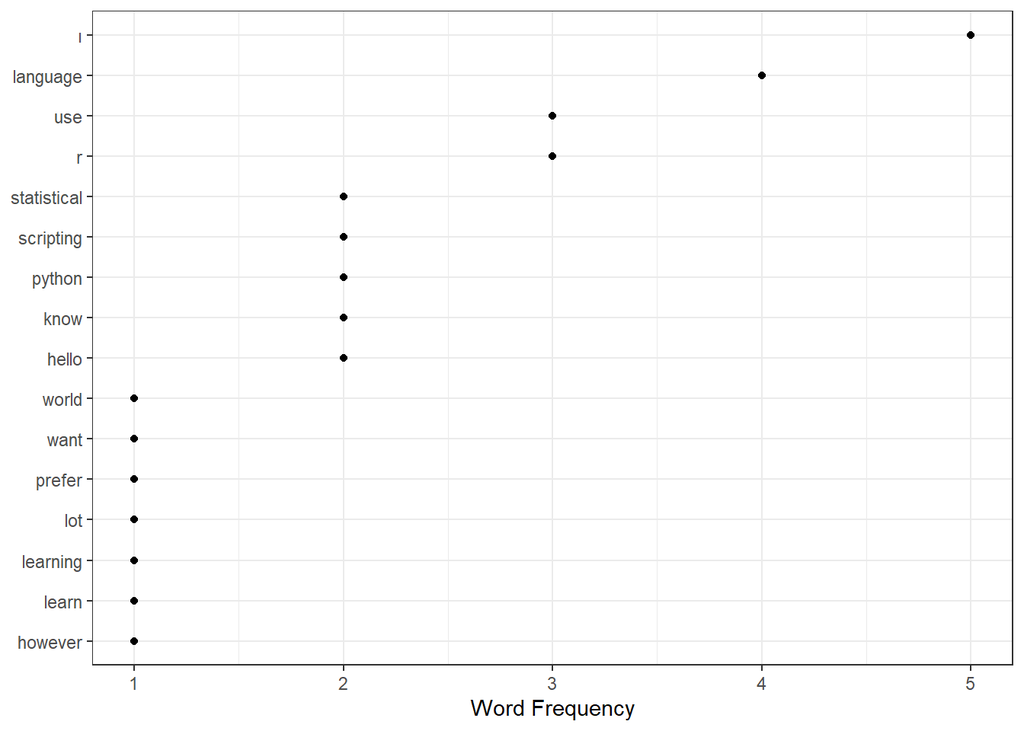

```r
tf <- textstat_frequency(lang_dfm)

tf <- as.data.table(tf)
tf[,feature:=reorder(feature,frequency)]

ggplot(tf,aes(x=feature,y=frequency))+geom_point()+coord_flip()+labs(x=NULL,y='Word Frequency')+theme_bw()
```

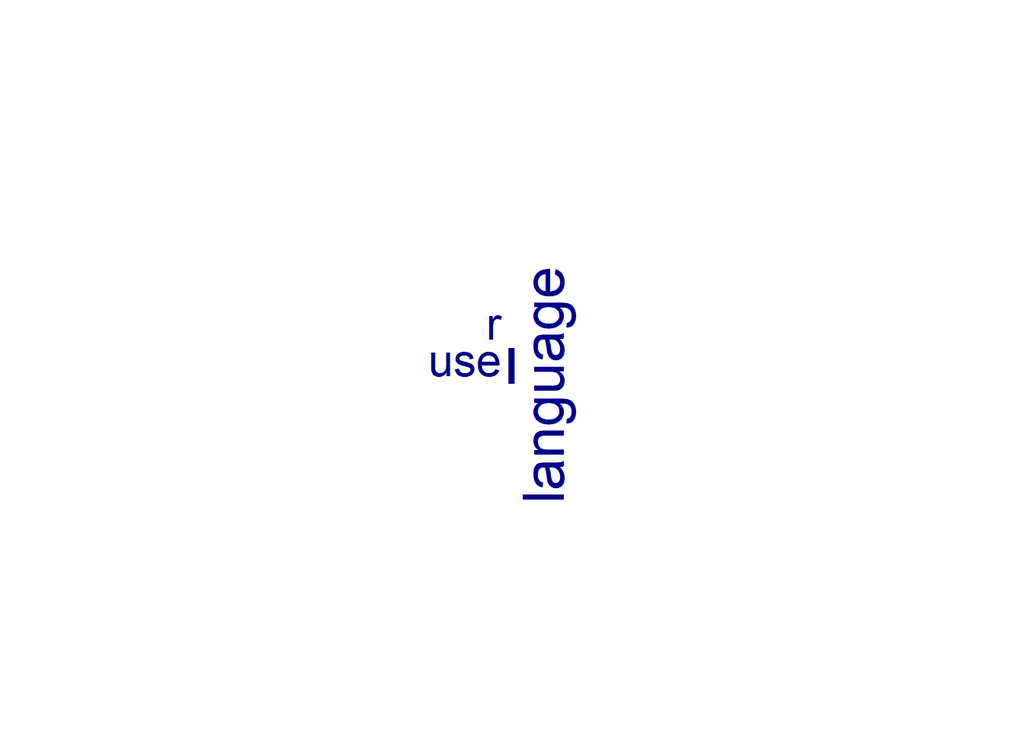

```r
textplot_wordcloud(lang_dfm)
```

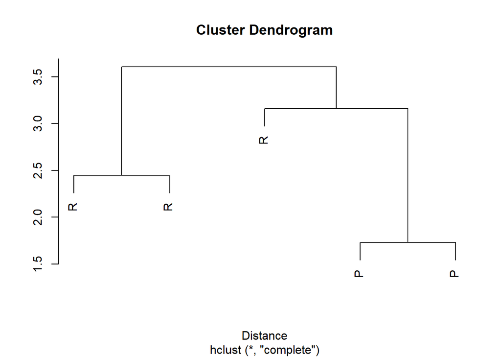

```r
lang_dist <- as.dist(textstat_dist(lang_dfm))
clust <- hclust(lang_dist)
plot(clust, xlab = "Distance", ylab = NULL,labels = lang_data[,group])
```

```r
lang_data
```

```
##                                                                                  text
## 1: Hello world! I am learning R which is a statistical language and I want to use it!
## 2:                                         Hello, I don't know R statistical language
## 3:                                  I know and use R. However, there is lot to learn!
## 4:                                     I prefer to use Python, a scripting language 1
## 5:                                              Python is a scripting language, 1 2 3
##    group
## 1:     R
## 2:     R
## 3:     R
## 4:     P
## 5:     P
```

### Word Embedding

In short, word embdding is the name of a technique that the vocabulary are mapped to vectors where similar words represented close to each other.

```r
lang_tokens.4 <-tokens(lang_data[,text],remove_numbers = T,remove_punct = T)
lang_tokens.4 <- lang_tokens.4%>%tokens_remove(pattern = stopwords('en'))


lang_fcm <- fcm(lang_tokens.4, context = "window", count = "weighted", weights = 1 / (1:4), tri = TRUE,window = 4)


glove <- GlobalVectors$new(rank = 50,
                           x_max = 10)

lang_embed <- glove$fit_transform(lang_fcm, n_iter = 10,
                                  convergence_tol = 0.01,
                                  n_threads = 8)
```

```
## INFO  [14:25:27.066] epoch 1, loss 0.1367
## INFO  [14:25:27.068] epoch 2, loss 0.0770
## INFO  [14:25:27.071] epoch 3, loss 0.0503
## INFO  [14:25:27.073] epoch 4, loss 0.0349
## INFO  [14:25:27.075] epoch 5, loss 0.0255
## INFO  [14:25:27.078] epoch 6, loss 0.0191
## INFO  [14:25:27.080] epoch 7, loss 0.0147
## INFO  [14:25:27.083] epoch 8, loss 0.0114
## INFO  [14:25:27.085] epoch 9, loss 0.0090
## INFO  [14:25:27.087] epoch 10, loss 0.0071
```

```r
wv_context <- glove$components

word_vectors <- lang_embed + t(wv_context)

Python <- word_vectors["R", , drop = FALSE] -
  word_vectors["statistical", , drop = FALSE]+word_vectors["scripting", , drop = FALSE]

cos_sim <- textstat_simil(x = as.dfm(word_vectors), y = as.dfm(Python),
                          method = "cosine")

head(sort(cos_sim[, 1], decreasing = TRUE), n = 5)
```

```
## scripting         R    Python      know     Hello
## 0.6124575 0.5387950 0.3879969 0.1876881 0.1577111
```

### Supervised Learning: Text Classification

```r
lang_dfm <- dfm(lang_tokens.3)
docnames(lang_dfm) <- 1:5

lang_training <- dfm_subset(lang_dfm,subset = docnames(lang_dfm) %in% c(1,2,5) )
lang_test <-dfm_subset(lang_dfm,subset = docnames(lang_dfm) %in% c(3,4) )

lang_model <- textmodel_nb(lang_training,lang_training$group)

summary(lang_model)
```

```
##
## Call:
## textmodel_nb.dfm(x = lang_training, y = lang_training$group)
##
## Class Priors:
## (showing first 2 elements)
##   P   R
## 0.5 0.5
##
## Estimated Feature Scores:
##     hello   world       ı learning       r statistical
## P 0.05263 0.05263 0.05263  0.05263 0.05263     0.05263
## R 0.09375 0.06250 0.12500  0.06250 0.09375     0.09375
##   language    want     use    know however     lot
## P  0.10526 0.05263 0.05263 0.05263 0.05263 0.05263
## R  0.09375 0.06250 0.06250 0.06250 0.03125 0.03125
##     learn  prefer  python scripting
## P 0.05263 0.05263 0.10526   0.10526
## R 0.03125 0.03125 0.03125   0.03125
```

```r
lang_test <- dfm_match(lang_test,featnames(lang_training))

actual_class <- lang_test$group
predicted_class <- predict(lang_model, newdata = lang_test)
tab_class <- table(actual_class, predicted_class)
tab_class
```

```
##             predicted_class
## actual_class P R
##            P 1 0
##            R 0 1
```

```r
confusionMatrix(tab_class, mode = "everything")
```

```
## Confusion Matrix and Statistics
##
##             predicted_class
## actual_class P R
##            P 1 0
##            R 0 1
##
##                Accuracy : 1
##                  95% CI : (0.1581, 1)
##     No Information Rate : 0.5
##     P-Value [Acc > NIR] : 0.25
##
##                   Kappa : 1
##
##  Mcnemar's Test P-Value : NA
##
##             Sensitivity : 1.0
##             Specificity : 1.0
##          Pos Pred Value : 1.0
##          Neg Pred Value : 1.0
##               Precision : 1.0
##                  Recall : 1.0
##                      F1 : 1.0
##              Prevalence : 0.5
##          Detection Rate : 0.5
##    Detection Prevalence : 0.5
##       Balanced Accuracy : 1.0
##
##        'Positive' Class : P
##
```

### Unsupervised Learning: Topic Models

In this section we are not providing labels to the classifier. We only provide how many topics will be in the model. Then the algorithm distribute fetures to topics and topics to documents. I will use stm package to train topic models but you can try LDA as well. Since we are working with a dwarf data set the results are not pretty!

```r
lang_topic_model <- stm(documents = lang_dfm,K = 2,data = data.table(lang_dfm$group))
```

[output not shown]

[output cut: 228 more lines]

[output not shown]

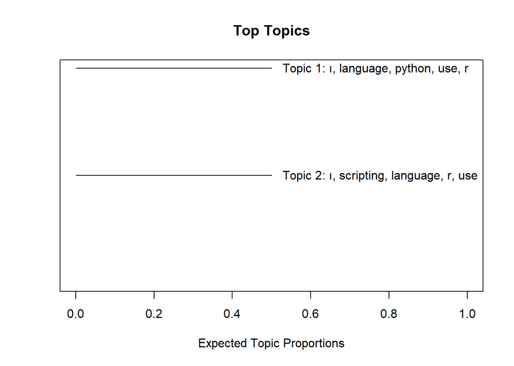

```r
plot(lang_topic_model,n = 5)
```

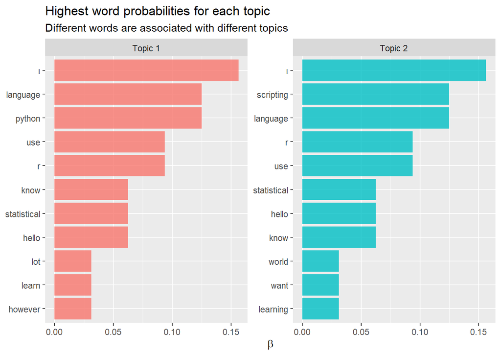

```r
td_beta <- tidy(lang_topic_model)

td_beta %>%
  group_by(topic) %>%
  top_n(10, beta) %>%
  ungroup() %>%
  mutate(topic = paste0("Topic ", topic),
         term = reorder_within(term, beta, topic)) %>%
  ggplot(aes(term, beta, fill = as.factor(topic))) +
  geom_col(alpha = 0.8, show.legend = FALSE) +
  facet_wrap(~ topic, scales = "free_y") +
  coord_flip() +
  scale_x_reordered() +
  labs(x = NULL, y = expression(beta),
       title = "Highest word probabilities for each topic",
       subtitle = "Different words are associated with different topics")
```

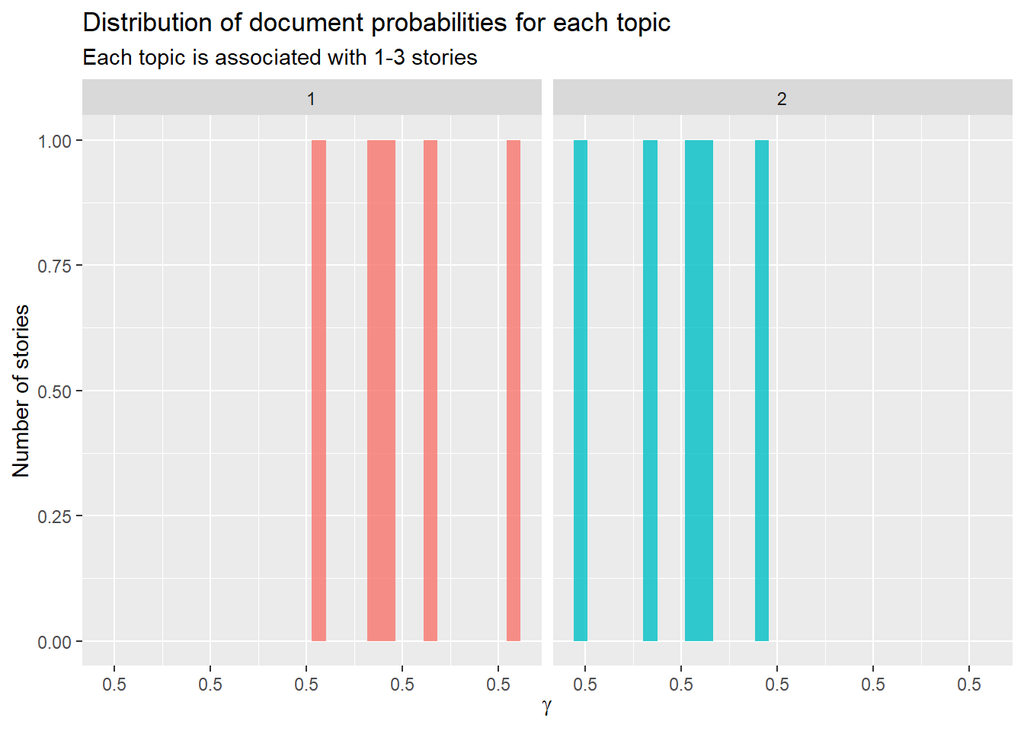

```r
td_gamma <- tidy(lang_topic_model, matrix = "gamma",
                 document_names = rownames(lang_topic_model))

ggplot(td_gamma, aes(gamma, fill = as.factor(topic))) +
  geom_histogram(alpha = 0.8, show.legend = FALSE) +
  facet_wrap(~ topic) +
  labs(title = "Distribution of document probabilities for each topic",
       subtitle = "Each topic is associated with 1-3 stories",
       y = "Number of stories", x = expression(gamma))
```